# A practical introduction to regression

Damian Pavlyshyn

26 May 2023

# The structure of a data table

```r
data(birthwt, package = "MASS")
head(birthwt)
```

| birth_weight | m_age | m_weight | m_race | m_smoker | m_prem_labors | m_hist_hyper | m_uter_irrit | m_doc_visits |
| --- | --- | --- | --- | --- | --- | --- | --- | --- |
| 2.52 | 19 | 82.55 | black | FALSE | 0 | FALSE | TRUE | 0 |
| 2.55 | 33 | 70.31 | other | FALSE | 0 | FALSE | FALSE | 3 |
| 2.56 | 20 | 47.63 | white | TRUE | 0 | FALSE | FALSE | 1 |
| 2.59 | 21 | 48.99 | white | TRUE | 0 | FALSE | TRUE | 2 |
| 2.60 | 18 | 48.53 | white | TRUE | 0 | FALSE | TRUE | 0 |
| 2.62 | 21 | 56.25 | other | FALSE | 0 | FALSE | FALSE | 0 |

## Training data

Contains measurements of all variables.

```r
birthwt_train <- slice_sample(birthwt, prop = 0.9)
```

| birth_weight | m_age | m_weight | m_race | m_smoker | m_prem_labors | m_hist_hyper | m_uter_irrit | m_doc_visits |
| --- | --- | --- | --- | --- | --- | --- | --- | --- |
| 1.89 | 19 | 41.28 | white | TRUE | 2 | FALSE | TRUE | 0 |
| 3.10 | 22 | 54.43 | white | FALSE | 0 | TRUE | FALSE | 1 |
| 2.08 | 19 | 46.27 | white | FALSE | 0 | FALSE | FALSE | 2 |
| 3.20 | 30 | 69.40 | other | FALSE | 0 | FALSE | FALSE | 0 |
| 3.63 | 19 | 106.59 | white | TRUE | 0 | TRUE | FALSE | 0 |
| 3.37 | 16 | 61.23 | white | TRUE | 0 | FALSE | FALSE | 0 |

## New data

Only contains measurements of covariates … but we’d like to know the outcome

```r
birthwt_new <- birthwt %>%
  anti_join(birthwt_train) %>%
  select(-birth_weight)
```

| m_age | m_weight | m_race | m_smoker | m_prem_labors | m_hist_hyper | m_uter_irrit | m_doc_visits |
| --- | --- | --- | --- | --- | --- | --- | --- |
| 20 | 54.43 | other | FALSE | 0 | FALSE | TRUE | 0 |
| 17 | 55.34 | white | TRUE | 0 | FALSE | FALSE | 0 |
| 23 | 58.97 | black | FALSE | 0 | FALSE | FALSE | 1 |
| 23 | 58.06 | other | FALSE | 0 | FALSE | FALSE | 0 |
| 30 | 43.09 | white | TRUE | 0 | FALSE | FALSE | 2 |
| 32 | 60.78 | white | TRUE | 1 | FALSE | FALSE | 4 |

# Regression

How can we use the measurements in the training data to inform our guesses about the outcome in the new data?

## Step 1: Fit/train/learn a model

Ingredients:

1. **Type of model** : How complicated can the relationships between covariates and outcome be?
2. **Formula** : Which outcome and covariates are we considering?
3. **Training data** : Which measurements are we using to inform our guesses?

```r
fit <- lm(
  formula = birth_weight ~ m_age + m_weight + m_smoker + m_prem_labors,
  data    = birthwt_train
)
```

## Step 2: Predict outcomes

```r
new_obs <- birthwt_new[1:5, ]
```

| m_age | m_weight | m_race | m_smoker | m_prem_labors | m_hist_hyper | m_uter_irrit | m_doc_visits |
| --- | --- | --- | --- | --- | --- | --- | --- |
| 20 | 54.43 | other | FALSE | 0 | FALSE | TRUE | 0 |
| 17 | 55.34 | white | TRUE | 0 | FALSE | FALSE | 0 |
| 23 | 58.97 | black | FALSE | 0 | FALSE | FALSE | 1 |
| 23 | 58.06 | other | FALSE | 0 | FALSE | FALSE | 0 |
| 30 | 43.09 | white | TRUE | 0 | FALSE | FALSE | 2 |

What’s our best educated guess for the birth weight of these people’s children?

```r
predict(fit, newdata = new_obs)
```

```
##        1        2        3        4        5
## 2.985043 2.715692 3.037831 3.029939 2.666900
```

# How did `predict()` make that calculation?

```r
summary(fit)
```

```
##
## Call:
## lm(formula = birth_weight ~ m_age + m_weight + m_smoker + m_prem_labors,
##     data = birthwt_train)
##
## Residuals:
##      Min       1Q   Median       3Q      Max
## -2.04349 -0.46118 -0.01145  0.49653  1.88205
##
## Coefficients:
##                Estimate Std. Error t value Pr(>|t|)
## (Intercept)    2.422660   0.311950   7.766 8.12e-13 ***
## m_age          0.004443   0.010529   0.422   0.6736
## m_weight       0.008700   0.003946   2.205   0.0289 *
## m_smokerTRUE  -0.263915   0.114576  -2.303   0.0225 *
## m_prem_labors -0.115341   0.112220  -1.028   0.3055
## ---
## Signif. codes:  0 '***' 0.001 '**' 0.01 '*' 0.05 '.' 0.1 ' ' 1
##
## Residual standard error: 0.7146 on 165 degrees of freedom
## Multiple R-squared:  0.07915,    Adjusted R-squared:  0.05682
## F-statistic: 3.545 on 4 and 165 DF,  p-value: 0.008366
```

## Significance: will dropping this variable change the predictions?

```r
predict(fit, newdata = new_obs)
```

```
##        1        2        3        4        5
## 2.985043 2.715692 3.037831 3.029939 2.666900
```

What happens if we remove the non-significant variable `m_age`?

```r
fit_no_age <- lm(
  formula = birth_weight ~ m_weight + m_smoker + m_prem_labors,
  data    = birthwt_train
)

predict(fit_no_age, newdata = new_obs)
```

```
##        1        2        3        4        5
## 2.997543 2.739253 3.038551 3.030349 2.628531
```

How about the significant `m_smoker`?

```r
fit_no_smoker <- lm(
  formula = birth_weight ~ m_age + m_weight + m_prem_labors,
  data    = birthwt_train
)

predict(fit_no_smoker, newdata = new_obs)
```

```
##        1        2        3        4        5
## 2.889462 2.880035 2.945557 2.937779 2.849588
```

# A one-covariate example

Let’s just look at the relationship between birth weight and maternal weight

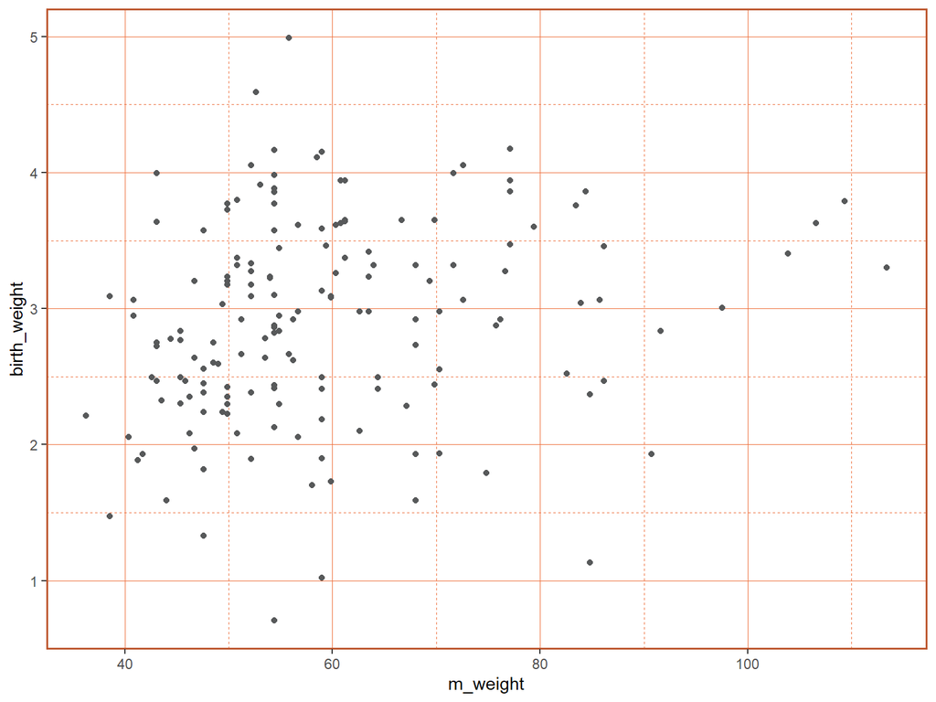

```r
p <- birthwt_train %>%
  ggplot(aes(y = birth_weight, x = m_weight)) +
  geom_point(color = g3) +
  theme_burnet
```

We train of model with a new, simple formula

```r
weight_fit <- lm(
  formula = birth_weight ~ m_weight,
  data    = birthwt_train
)
```

Now, let’s see what the predicted birth weights are for a number of evenly-spaced maternal weights:

```r
spaced_weights <- tibble(
  m_weight = c(30, 40, 50, 60, 70, 80, 90, 100, 110)
)

predict(weight_fit, newdata = spaced_weights)
```

```
##        1        2        3        4        5        6        7        8
## 2.629677 2.727985 2.826293 2.924601 3.022909 3.121217 3.219525 3.317833
##        9
## 3.416141
```

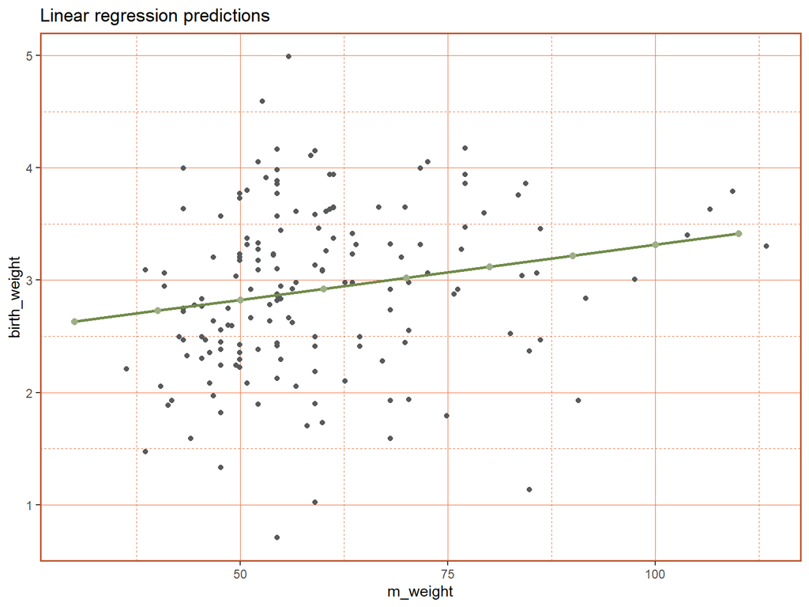

```r
summary(weight_fit)
```

```
##
## Call:
## lm(formula = birth_weight ~ m_weight, data = birthwt_train)
##
## Residuals:
##     Min      1Q  Median      3Q     Max
## -2.1608 -0.4728  0.0067  0.4764  2.1068
##
## Coefficients:
##             Estimate Std. Error t value Pr(>|t|)
## (Intercept) 2.334753   0.235627   9.909   <2e-16 ***
## m_weight    0.009831   0.003869   2.541    0.012 *
## ---
## Signif. codes:  0 '***' 0.001 '**' 0.01 '*' 0.05 '.' 0.1 ' ' 1
##
## Residual standard error: 0.7242 on 168 degrees of freedom
## Multiple R-squared:  0.03701,    Adjusted R-squared:  0.03127
## F-statistic: 6.456 on 1 and 168 DF,  p-value: 0.01196
```

## Bonus: local linear regression

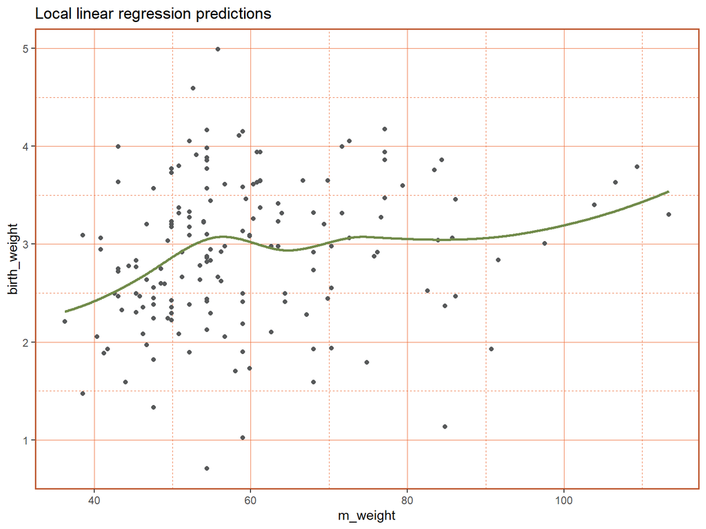

## Bonus: gradient-boosted tree regression

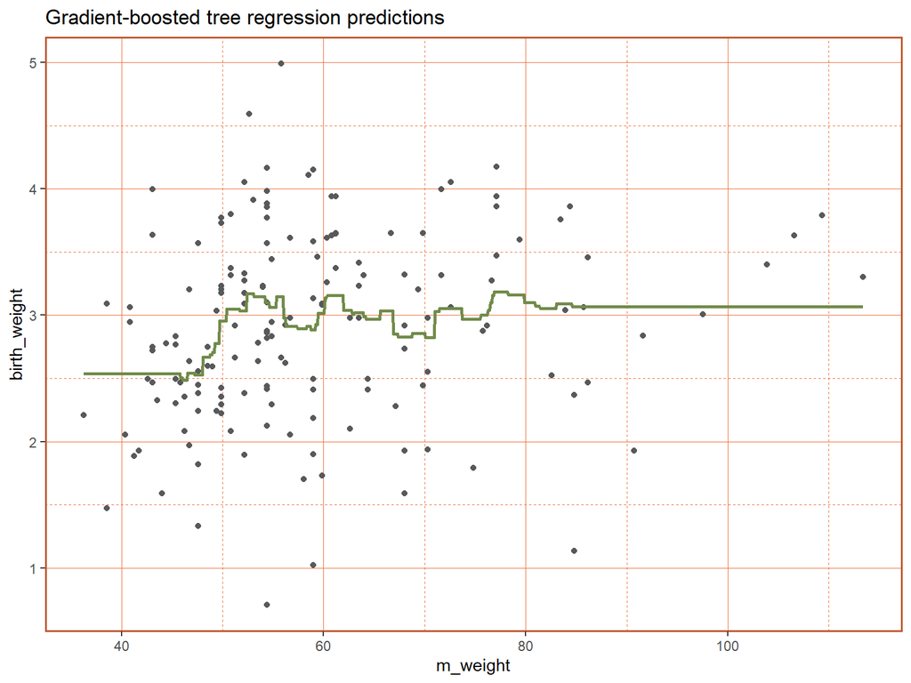

# Problematic cases

You can run a linear regression on any data … but the result may be meaningless!

`summary()` will never give you the whole story!

## What if the model is wrong?

```r
fit <- lm(y ~ time, data = df)
summary(fit)
```

```
##
## Call:
## lm(formula = y ~ time, data = df)
##
## Residuals:
##    Min     1Q Median     3Q    Max
## -5.145 -2.803 -1.165  1.915 20.722
##
## Coefficients:
##             Estimate Std. Error t value Pr(>|t|)
## (Intercept)  -3.0997     0.7787  -3.981 0.000132 ***
## time          3.7385     0.2268  16.485  < 2e-16 ***
## ---
## Signif. codes:  0 '***' 0.001 '**' 0.01 '*' 0.05 '.' 0.1 ' ' 1
##
## Residual standard error: 3.983 on 98 degrees of freedom
## Multiple R-squared:  0.735,  Adjusted R-squared:  0.7322
## F-statistic: 271.7 on 1 and 98 DF,  p-value: < 2.2e-16
```

Let’s plot the data

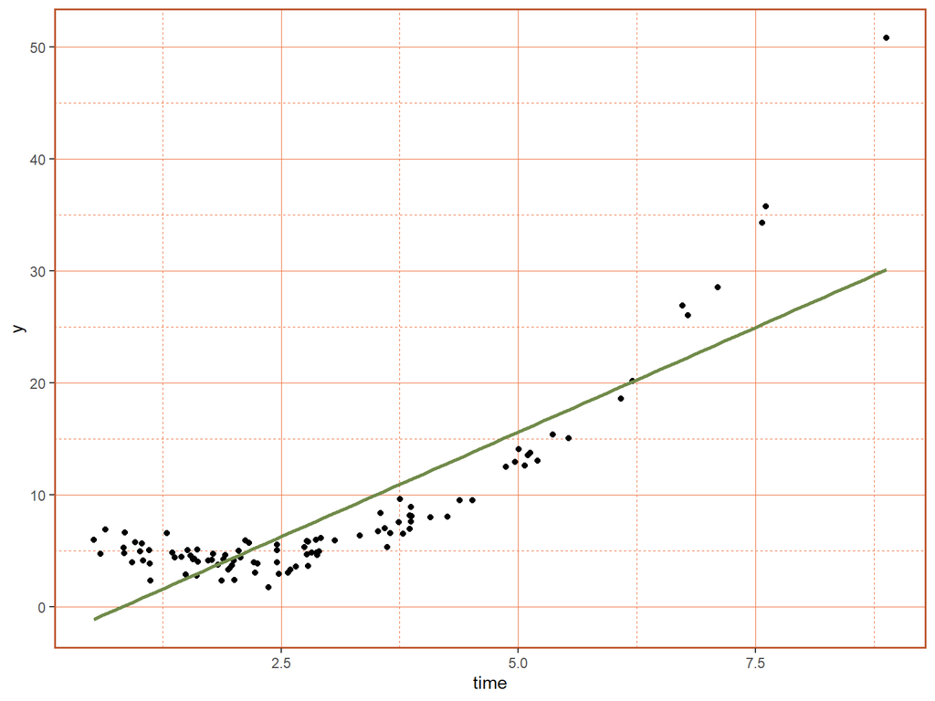

```r
df %>%
  ggplot(aes(x = time, y = y)) +
  geom_point() +
  stat_smooth(method = "lm", se = FALSE, color = g_accent) +
  theme_burnet
```

The residuals are the errors in our predictions.

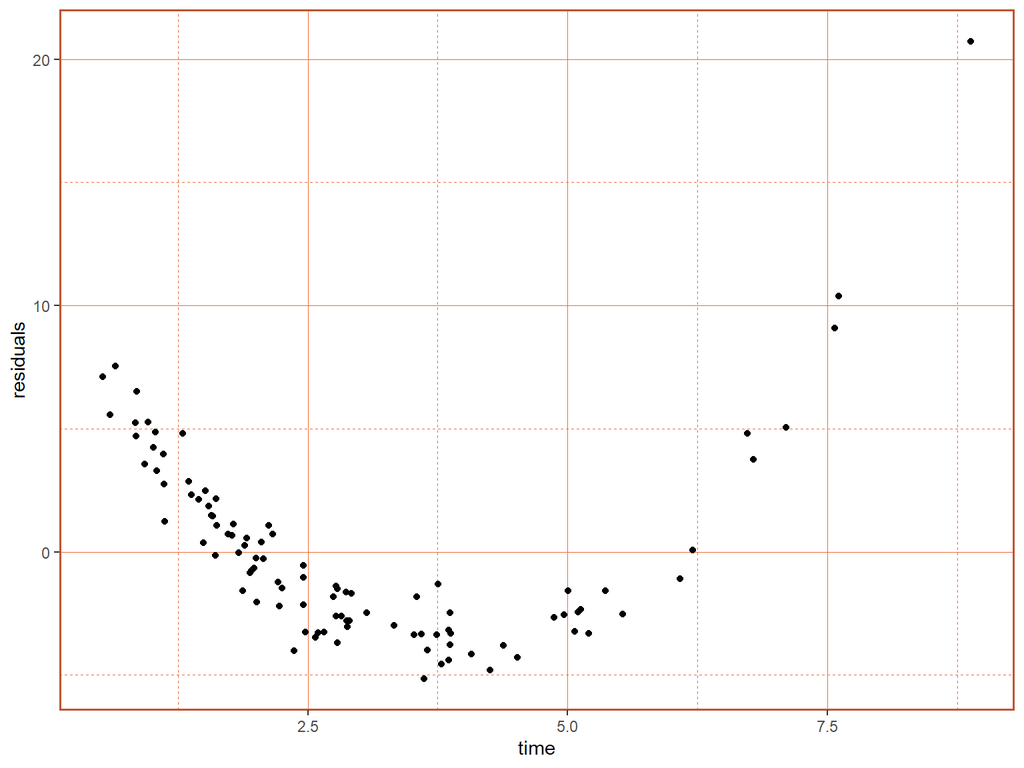

```r
residuals <- resid(fit)

df %>%
  ggplot(aes(x = time, y = residuals)) +
  geom_point() +
  theme_burnet
```

Unbiased residuals:

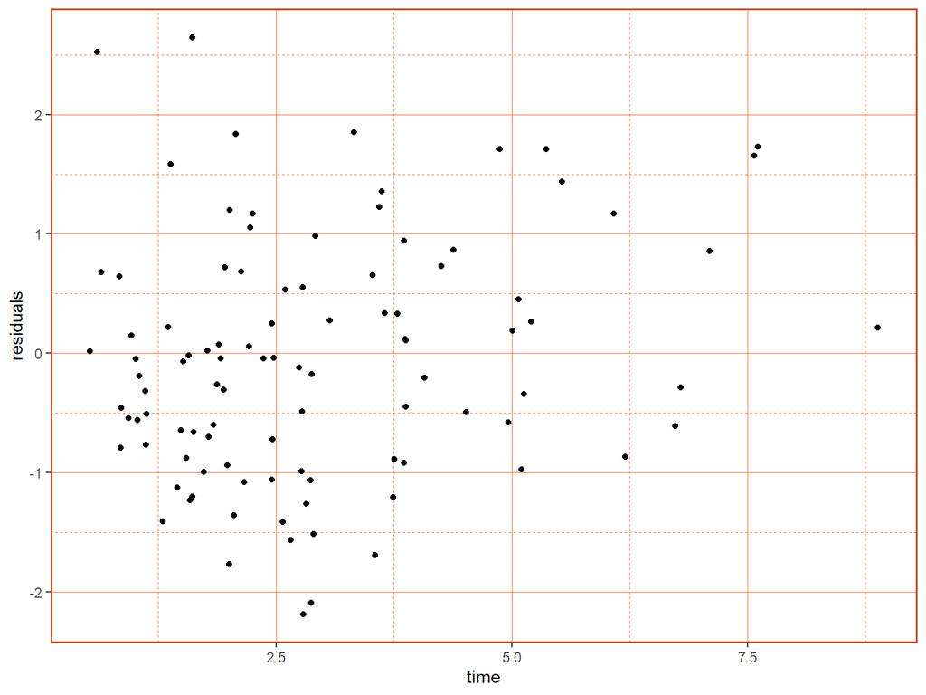

## What if the noise is not Gaussian?

Try to estimate the number of centimetres in an inch by measuring a bunch of objects with a good centimetre ruler and a really terrible inch ruler.

```r
n_obs <- 1000

df <- tibble(
  len_cm = rnorm(n_obs, mean = 10),
  len_in = 2.54 * len_cm + rcauchy(n_obs)
)
```

Fit the model and find the slope - we expect it to be around 2.54:

```r
fit <- lm(len_in ~ len_cm, data = df)
summary(fit)
```

```
##
## Call:
## lm(formula = len_in ~ len_cm, data = df)
##
## Residuals:
##    Min     1Q Median     3Q    Max
## -92.48  -2.57  -1.26   0.00 371.75
##
## Coefficients:
##             Estimate Std. Error t value Pr(>|t|)
## (Intercept)   10.920      6.256   1.745   0.0812 .
## len_cm         1.581      0.623   2.537   0.0113 *
## ---
## Signif. codes:  0 '***' 0.001 '**' 0.01 '*' 0.05 '.' 0.1 ' ' 1
##
## Residual standard error: 20.38 on 998 degrees of freedom
## Multiple R-squared:  0.006409,   Adjusted R-squared:  0.005413
## F-statistic: 6.437 on 1 and 998 DF,  p-value: 0.01133
```

Let’s have a look at the data

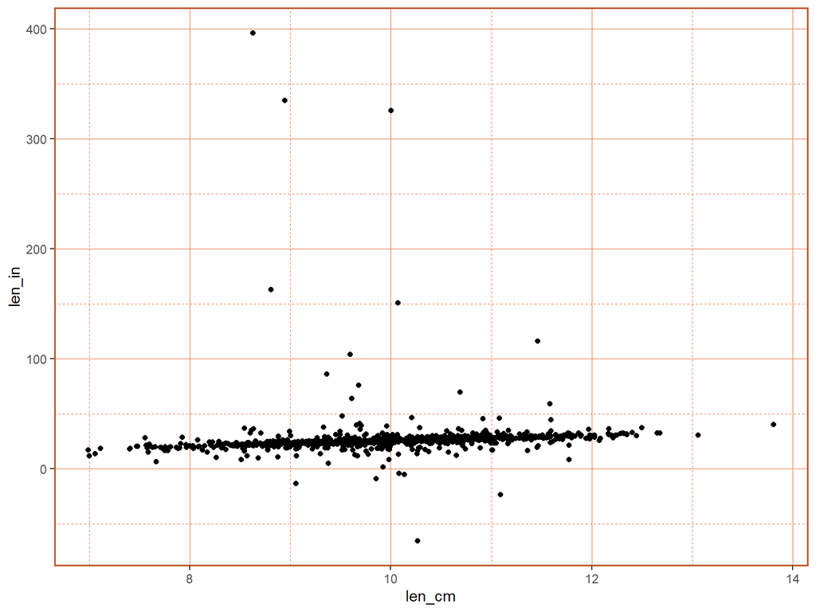

```r
df %>%
  ggplot(aes(y = len_in, x = len_cm)) +
  geom_point() +
  theme_burnet
```

Check if the residuals are normally distributed

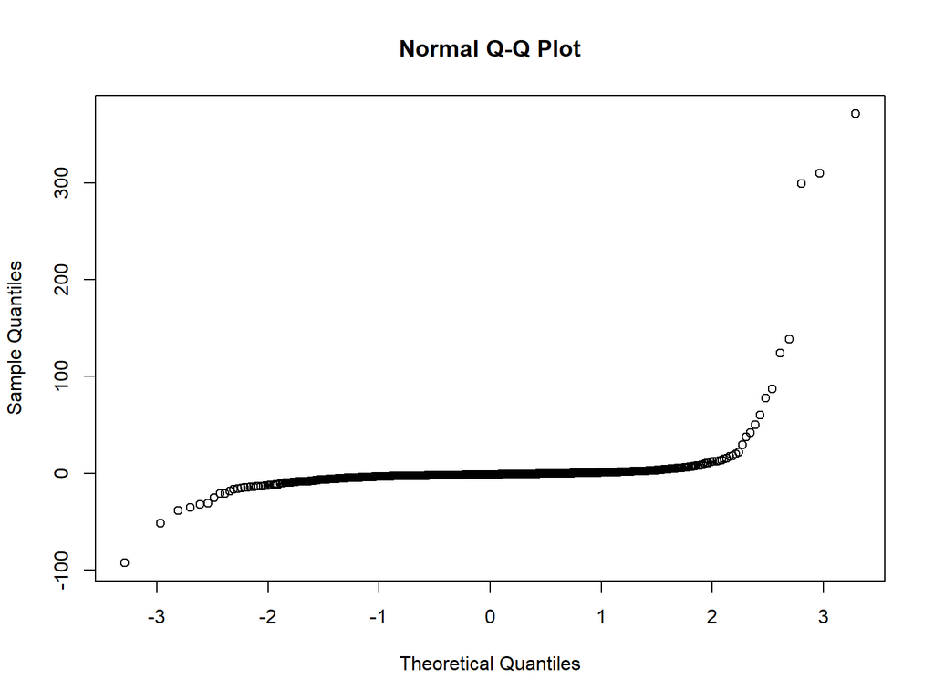

```r
resid <- resid(fit)
qqnorm(resid)
```

Normally distributed residuals

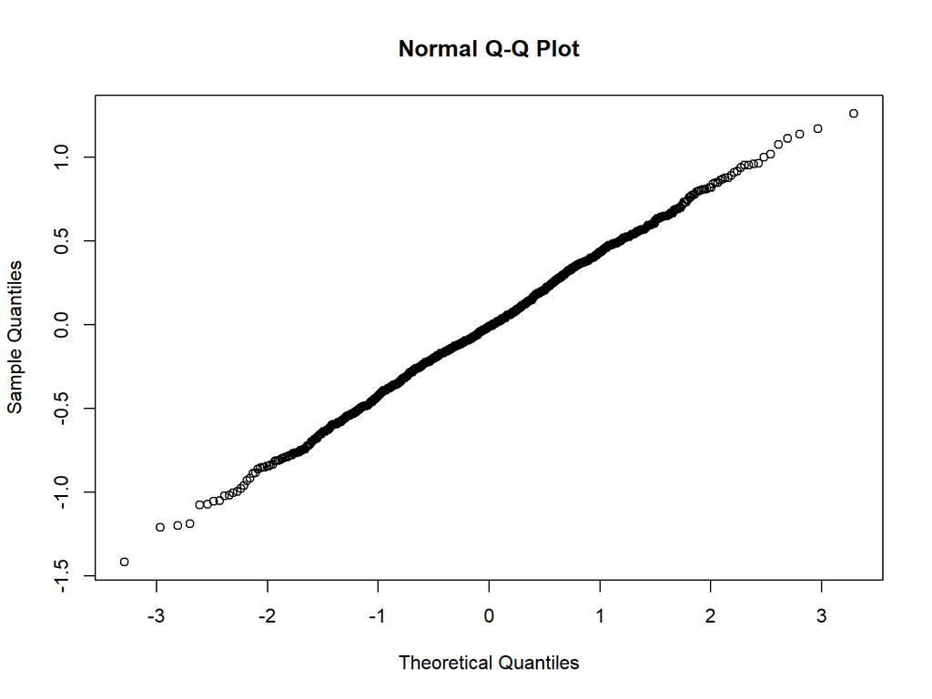